# BaitCap Analysis

Jessica Rowell

9/8/2021

# Background on the problem

**Objective**: Evaluate how well a laboratory method captures Shiga toxin-producing *E. coli* (STEC) from complex samples that also contain commensal (non-pathogenic) *E. coli* strains. Pathogenic and commensal *E. coli* are very similar and detecting STEC when it exists in along with commensal *E. coli* is an important problem for outbreak detection and surveillance. Bait capture method: My team members would like to evaluate a laboratory method called “bait capture” in comparison to a gold standard (shotgun sequencing). Briefly, bait capture involves first designing “baits” that bind to specific pieces of DNA. The desired DNA targets are captured, amplified, and then sequenced. The result is a set of sequences that are enriched for the DNA targets of interest.

**Shotgun method**: Shotgun sequencing involves chopping up long strands of DNA into small fragments and then sequencing all these fragments. In a sample with many different species, the small fragment sequences (called “short reads”) get all mixed up and we have to use computational techniques (like binning) to assemble the genomes and determine what species were in the original sample. Theoretically, this is an unbiased technique because everything gets sequenced equally (no enrichment of certain targets).

We are comparing the bait capture method against this method to determine how good bait capture is at capturing STEC in samples containing STEC and commensal *E. coli* strains.

**Replicates**: The baitcap vs. shotgun comparison was made in triplicate. The need for this analysis (i.e. this entire problem statement) stems from how the replicates were made. Each replicate was sourced from a separate solution containing STEC and commensal *E. coli* in a specified ratio. For example, if the specified ratio is 1:1, then a lab technician made 3 separate solutions of 1:1. Because the quantities are very small, there is substantial room for measurement error. We no longer have a known starting ratio for comparison. That’s why we need a method that compares baitcap to shotgun per replicate.

This contrasts with the other way this experiment has been done. That time, 1 main solution was made containing STEC and commensal in the prespecified ratio. 3 separate samples were taken from that solution, and then baitcap and shotgun were run on each of those 3 samples. In this scenario, the ratio in the samples taken from the main solution should follow the normal distribution (I wouldn’t expect it to be exactly the prespecified ratio every time), with a small variance. In that case, there isn’t much need for a special approach. Since it was done differently this time, we must do the analysis differently to take into account that we don’t have a reliable, known ratio for each of our 3 replicates.

# Exploratory analysis

## Taking a look at the data

### Data tables

Input data for graphs and models

type = C2C1, comparison = C2 means this row compares C2 to C1  
rep = replicate number  
z = logY(baitcap) - logY(shotgun), where Y = reads baitcap / reads shotgun

Table 1. Input data for graphs and models

| type | comparison | rep | z |
| --- | --- | --- | --- |
| C2C1 | C2 | 1 | -0.6899549 |
| C2C1 | C2 | 2 | -0.3926774 |
| C2C1 | C2 | 3 | -0.1783091 |
| FC1 | F | 1 | 0.2034167 |
| FC1 | F | 2 | 0.2547066 |
| FC1 | F | 3 | 0.5885684 |
| KC1 | K | 1 | 0.1115875 |
| KC1 | K | 2 | 0.1851309 |
| KC1 | K | 3 | -0.0719776 |
| NC1 | N | 1 | -0.8062599 |
| NC1 | N | 2 | -0.4437322 |
| NC1 | N | 3 | -0.1707488 |

Raw input data that can be used to check the numbers for Y, logY, and z above.

type = group indicator (C2C1 indicates that’s a C1 or C2 comparison row)  
comparison = this couples with “type”; type = C2C1 means it’s a C2 vs. C1, and comparison indicates which row it is  
bc = indicates baitcap (1) vs. shotgun (0)  
rep = replicate number  
outcome = number of reads

Table 2. Raw input data

| type | comparison | bc | rep | outcome | y | logY |
| --- | --- | --- | --- | --- | --- | --- |
| C2C1 | C1 | 0 | 1 | 436478 | NA | NA |
| C2C1 | C2 | 0 | 1 | 1234094 | 2.8273911 | 1.0393544 |
| C2C1 | C1 | 1 | 1 | 749924 | NA | NA |
| C2C1 | C2 | 1 | 1 | 1063554 | 1.4182157 | 0.3493995 |
| C2C1 | C1 | 0 | 2 | 726636 | NA | NA |
| C2C1 | C2 | 0 | 2 | 1716316 | 2.3620024 | 0.8595097 |
| C2C1 | C1 | 1 | 2 | 1040912 | NA | NA |
| C2C1 | C2 | 1 | 2 | 1660186 | 1.5949341 | 0.4668324 |
| C2C1 | C1 | 0 | 3 | 472832 | NA | NA |
| C2C1 | C2 | 0 | 3 | 1048416 | 2.2173119 | 0.7962956 |
| C2C1 | C1 | 1 | 3 | 1270758 | NA | NA |
| C2C1 | C2 | 1 | 3 | 2357496 | 1.8551888 | 0.6179865 |
| FC1 | C1 | 0 | 1 | 498234 | NA | NA |
| FC1 | F | 0 | 1 | 774642 | 1.5547755 | 0.4413311 |
| FC1 | C1 | 1 | 1 | 814320 | NA | NA |
| FC1 | F | 1 | 1 | 1551692 | 1.9055064 | 0.6447478 |
| FC1 | C1 | 0 | 2 | 609786 | NA | NA |
| FC1 | F | 0 | 2 | 664352 | 1.0894839 | 0.0857041 |
| FC1 | C1 | 1 | 2 | 1557814 | NA | NA |
| FC1 | F | 1 | 2 | 2189546 | 1.4055247 | 0.3404107 |
| FC1 | C1 | 0 | 3 | 647186 | NA | NA |
| FC1 | F | 0 | 3 | 395658 | 0.6113513 | -0.4920835 |
| FC1 | C1 | 1 | 3 | 1401322 | NA | NA |
| FC1 | F | 1 | 3 | 1543266 | 1.1012929 | 0.0964849 |
| KC1 | C1 | 0 | 1 | 542488 | NA | NA |
| KC1 | K | 0 | 1 | 363722 | 0.6704701 | -0.3997761 |
| KC1 | C1 | 1 | 1 | 947848 | NA | NA |
| KC1 | K | 1 | 1 | 710526 | 0.7496202 | -0.2881886 |
| KC1 | C1 | 0 | 2 | 513918 | NA | NA |
| KC1 | K | 0 | 2 | 799854 | 1.5563845 | 0.4423655 |
| KC1 | C1 | 1 | 2 | 1198652 | NA | NA |
| KC1 | K | 1 | 2 | 2244974 | 1.8729156 | 0.6274963 |
| KC1 | C1 | 0 | 3 | 584424 | NA | NA |
| KC1 | K | 0 | 3 | 883666 | 1.5120289 | 0.4134524 |
| KC1 | C1 | 1 | 3 | 1460214 | NA | NA |
| KC1 | K | 1 | 3 | 2054552 | 1.4070212 | 0.3414748 |
| NC1 | C1 | 0 | 1 | 514756 | NA | NA |
| NC1 | N | 0 | 1 | 870196 | 1.6905019 | 0.5250255 |
| NC1 | C1 | 1 | 1 | 1174822 | NA | NA |
| NC1 | N | 1 | 1 | 886816 | 0.7548514 | -0.2812344 |
| NC1 | C1 | 0 | 2 | 631414 | NA | NA |
| NC1 | N | 0 | 2 | 1330742 | 2.1075586 | 0.7455302 |
| NC1 | C1 | 1 | 2 | 871974 | NA | NA |
| NC1 | N | 1 | 2 | 1179160 | 1.3522880 | 0.3017980 |
| NC1 | C1 | 0 | 3 | 422726 | NA | NA |
| NC1 | N | 0 | 3 | 1294646 | 3.0626127 | 1.1192684 |
| NC1 | C1 | 1 | 3 | 546734 | NA | NA |
| NC1 | N | 1 | 3 | 1411604 | 2.5818844 | 0.9485195 |

Our outcome variable of interest is the ratio of STEC reads to commensal reads. We want to compare this value for baitcap vs. shotgun sequencing. We want to account for the effect, if any, of replicate number, given the wet lab methodology.

First we visually check whether our outcome variable is normally distributed in our dataset. These look reasonable, especially considering the small number of observations (n = 12). For the QQ plot, the points should fall within the gray area, preferably as close to the line as possible. For the density plot, we’re looking for a nice “normal looking” curve, without much skew or bumps.

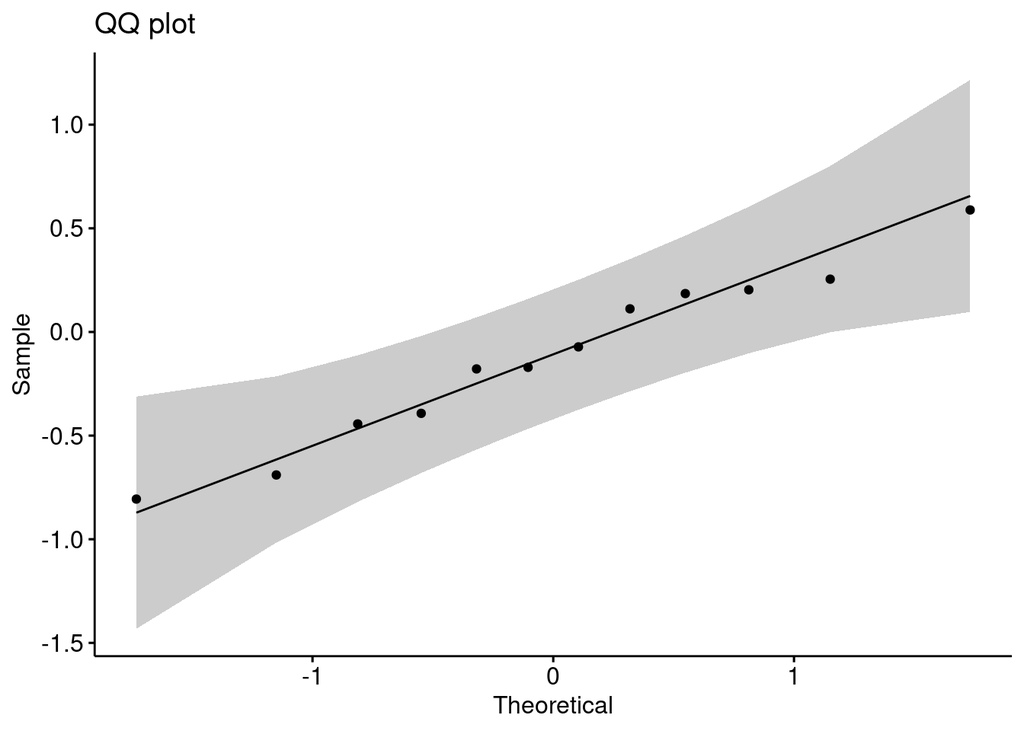

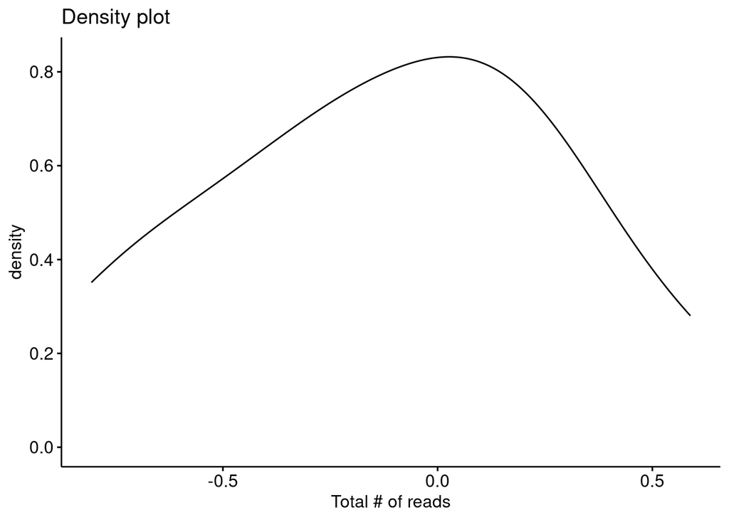

We may want to satisfy our curiosity by taking a quick look at how our outcome of interest compares for baitcap vs. shotgun. Here our outcome of interest is the ratio of total number of reads for STEC vs. commensal. In the plots below, the bold line in the box is the median and the box represents the interquartile range. So the middle half of the data resides within the box. The lines extend to cover 99.3% of the data. Any dots outside the lines are outliers. Very long boxes indicate a large variance, and low precision. For our small number of observations, a larger variance is not unexpected.

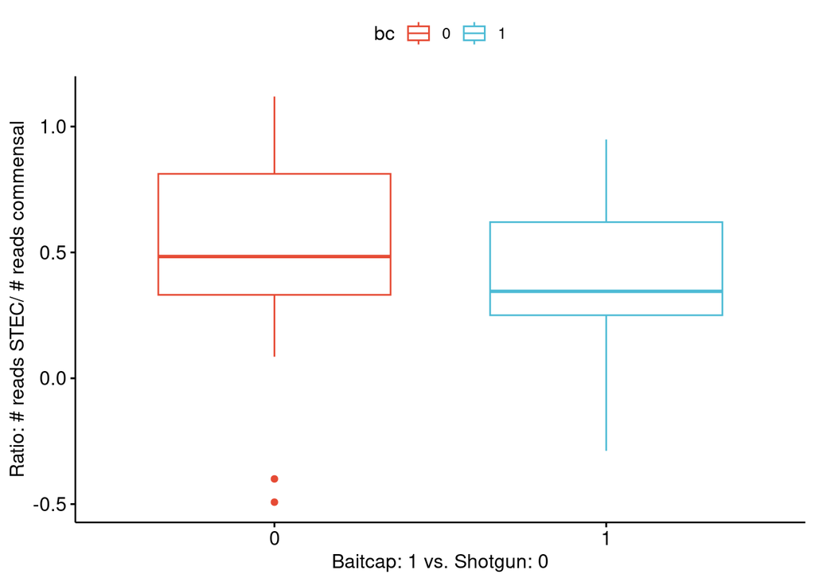

Now we visually check the distribution of that same ratio (# reads STEC vs. # reads commensal) across replicate number. While the medians are consistent across replicates, there is more variability in replicates 1 and 3 and the distributions look different.

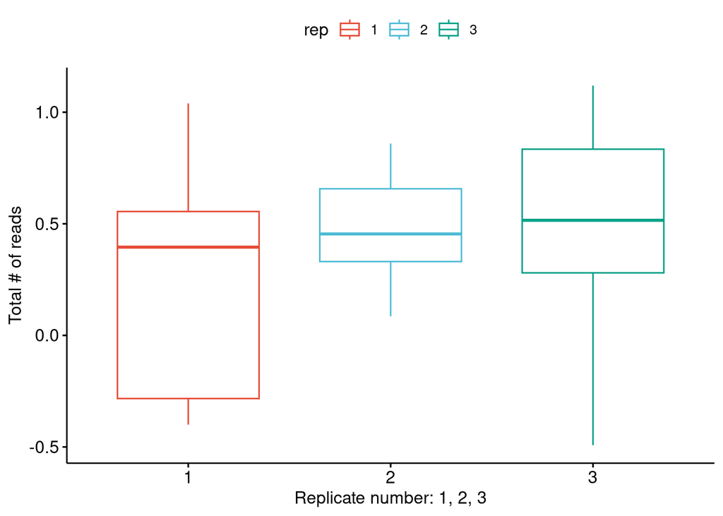

## First linear regression analysis: assume 12 independent samples

In this first analysis, we will treat the replicates as biological samples. So, we have 4 different biological sample comparisons: C2 vs. C1, F vs. C1, K vs. C1, N vs. C1. For each of those, there are 3 replicates.

Let’s call our outcome “z”. Z is the **difference** of the ratio of STEC-to-commensal for baitcap vs. shotgun. For analysis the ratios are log-transformed (as you see below).

$$y =
\frac{reads_{STEC}}{reads_{commensal}}$$

$$z = \log (y_{baitcap}) - \log
(y_{shotgun})$$

If we first consider each replicate as a separate, independent sample, we can just observe the average of z ($\mu_z$) in our whole dataset. This is equivalent to saying we did 12 separate tests of baitcap vs. shotgun, and we want to see what’s our best estimate of “z”.

The line we are fitting looks like this:

$$Z_i = \beta_0 + \epsilon, \space \space
\space i = 1,2,...,12$$
Some details to note: the residuals are not randomly distributed. Observations 6 and 10 could be influential. These two observations correspond to F vs. C1 (replicate 3) and N vs. C1 (replicate 1).

```
##
## Call:
## lm(formula = z ~ 1, data = d4)
##
## Residuals:
##      Min       1Q   Median       3Q      Max
## -0.68874 -0.28792 -0.00384  0.30722  0.70609
##
## Coefficients:
##             Estimate Std. Error t value Pr(>|t|)
## (Intercept)  -0.1175     0.1192  -0.986    0.346
##
## Residual standard error: 0.4131 on 11 degrees of freedom
```

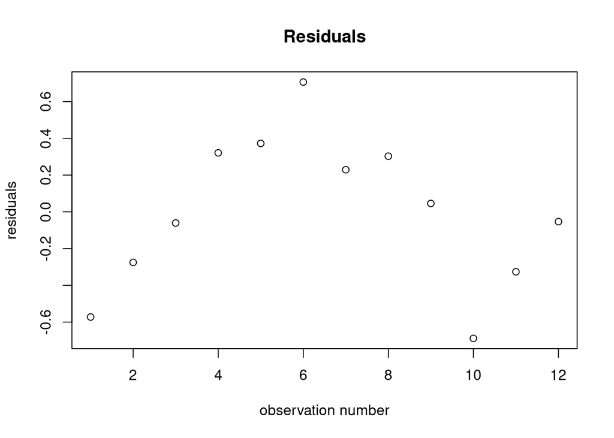

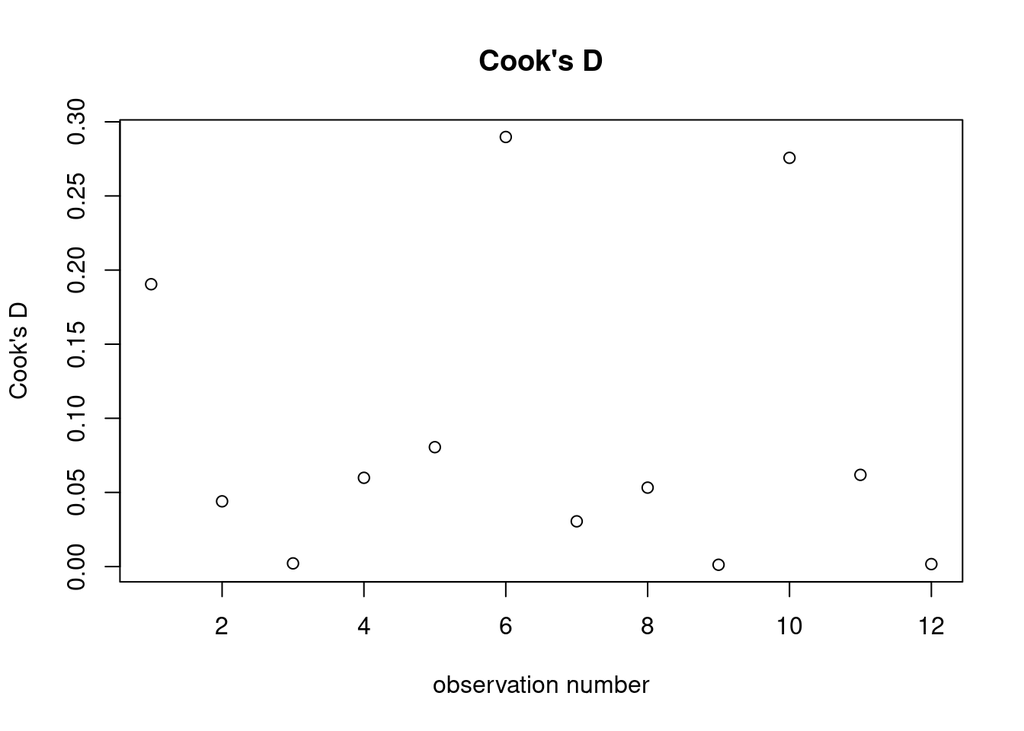

```
## [1] "Inverse ln(intercept): 0.889122002617685"
```

## Second linear regression analysis: assess the importance of replicate

Now we will introduce a variable for the effect of replicate on Z. The results of the linear regression suggest that replicate number does not significantly predict whether baitcap performs better than shotgun for detecting STEC vs. commensal *E. coli*.

```
##
## Call:
## lm(formula = z ~ as.factor(rep), data = d4)
##
## Residuals:
##     Min      1Q  Median      3Q     Max
## -0.5110 -0.3063 -0.1633  0.3671  0.5467
##
## Coefficients:
##                 Estimate Std. Error t value Pr(>|t|)
## (Intercept)      -0.2953     0.2139  -1.380    0.201
## as.factor(rep)2   0.1962     0.3025   0.648    0.533
## as.factor(rep)3   0.3372     0.3025   1.115    0.294
##
## Residual standard error: 0.4279 on 9 degrees of freedom
## Multiple R-squared:  0.1222, Adjusted R-squared:  -0.07283
## F-statistic: 0.6266 on 2 and 9 DF,  p-value: 0.5562
```

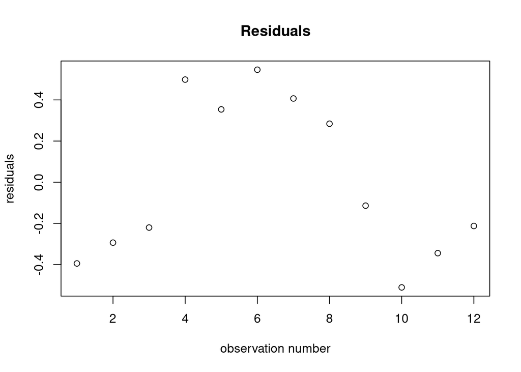

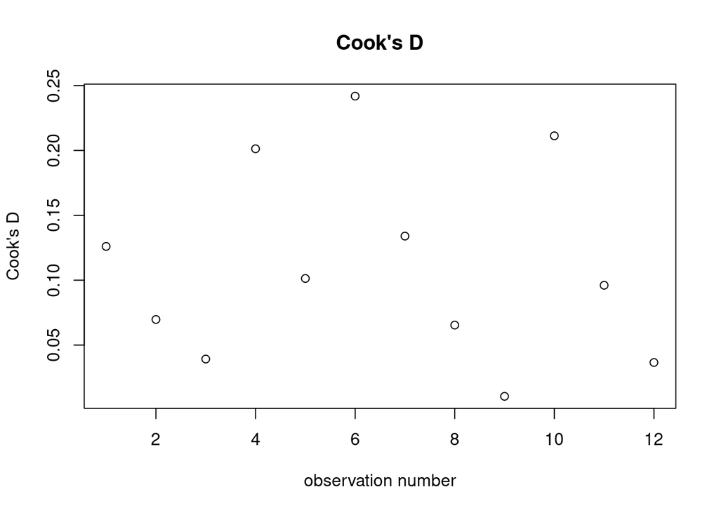

## Summary of linear regression analyses

In the figure below, we can see the following minor trend: baitcap performs a little better than shotgun for K vs. C1 and F vs. C1, but a little worse for N vs. C1 and C2 vs. C1. I’d say there is also a trend towards an effect of replicate number, and I would probably change the wet lab methodology if it’s not costly in time or other resources. With larger samples, independent replicates might become a problem. It would be interesting to repeat this analysis with replicates drawn from a single mixture, and compare the results with what we observe here.

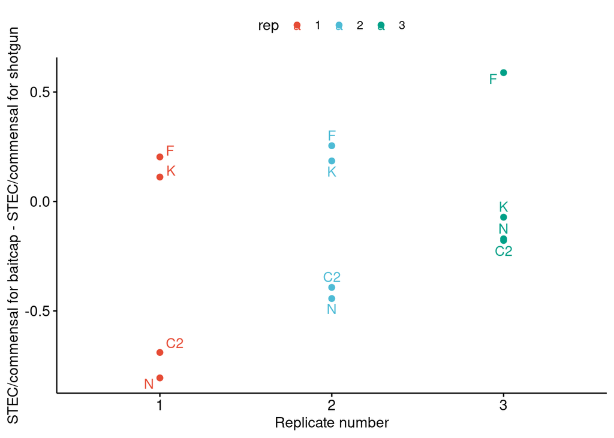

# Analysis of pilot baitcap study data

The figure below shows a comparison among different types: C2 vs. C1, F vs. C1, K vs. C1, and N vs. C1. Here our outcome of interest is the ratio of total number of reads for one type (C2, F, K, or N) vs. commensal (C1). In the plots below, the bold line in the box is the median and the box represents the interquartile range. So the middle half of the data resides within the box. The lines extend to cover 99.3% of the data. Any dots outside the lines are outliers. Very long boxes indicate a large variance, and low precision. For our small number of observations, a larger variance is not unexpected.

Here we observe that baitcap seems to capture more of its target STEC (F and K types) than commensal, compared to shotgun, but only when used on STEC for which the baits have been designed. The nonspecific target STEC, N, performed the same as the control group (C2 vs. C1).

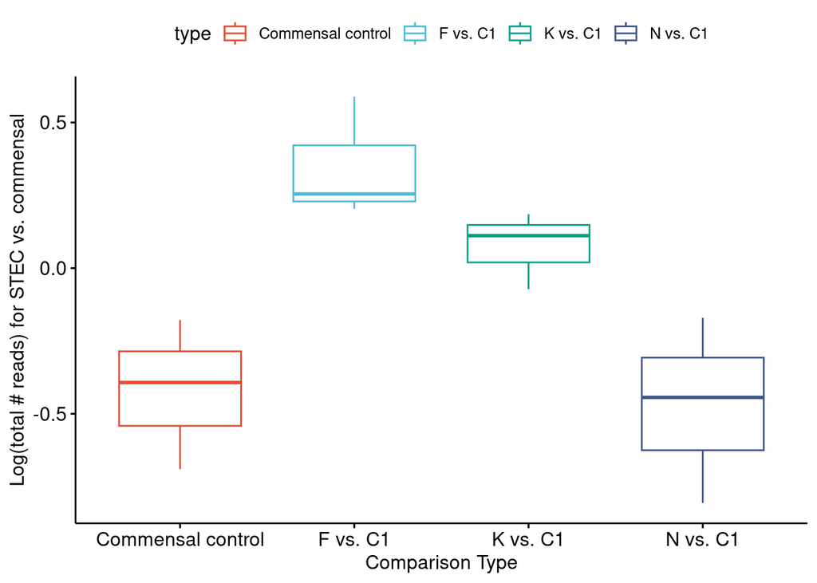

log(STEC/commensal) - BC log(STEC/commensal) - SS

outcome: log[(STEC/commensal)-BC / (STEC/commensal)-SS] **same as: log(STEC/commensal-BC) - log(STEC/commensal-SS)**

## Comparing target STEC vs. controls

Now I have collapsed the target STEC types (F and K) together and removed the non-target STEC group (N) to compare baitcap vs. shotgun performance in target STEC vs control.  
So now we are comparing two groups: one control group of 3 replicates (C2 vs. C1) and one experimental group comprising two sets of 3 replicates.

```
##
## Call:
## lm(formula = z ~ as.factor(type), data = d_sub)
##
## Residuals:
##      Min       1Q   Median       3Q      Max
## -0.28388 -0.10032 -0.00849  0.04280  0.37666
##
## Coefficients:
##                     Estimate Std. Error t value Pr(>|t|)
## (Intercept)          -0.4203     0.1322  -3.179  0.01552 *
## as.factor(type)FKC1   0.6322     0.1619   3.904  0.00587 **
## ---
## Signif. codes:  0 '***' 0.001 '**' 0.01 '*' 0.05 '.' 0.1 ' ' 1
##
## Residual standard error: 0.229 on 7 degrees of freedom
## Multiple R-squared:  0.6852, Adjusted R-squared:  0.6403
## F-statistic: 15.24 on 1 and 7 DF,  p-value: 0.00587
```

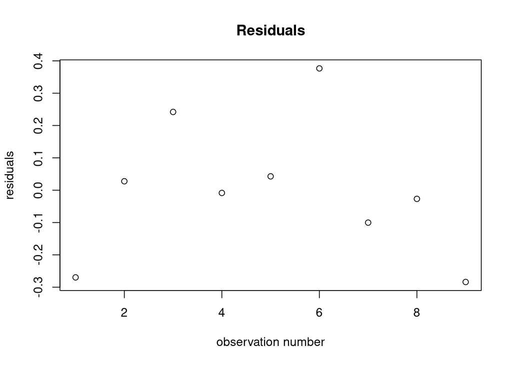

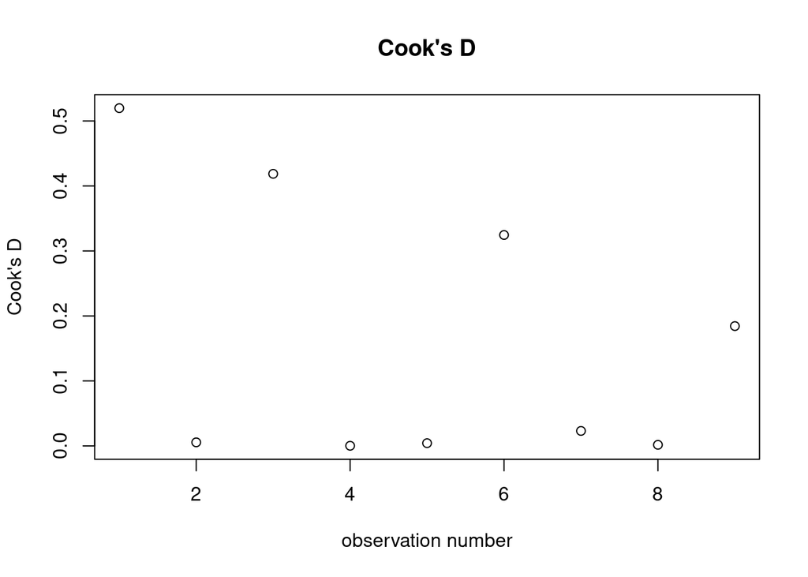

```
##         (Intercept) as.factor(type)FKC1
##           0.6568407           1.8817820
```

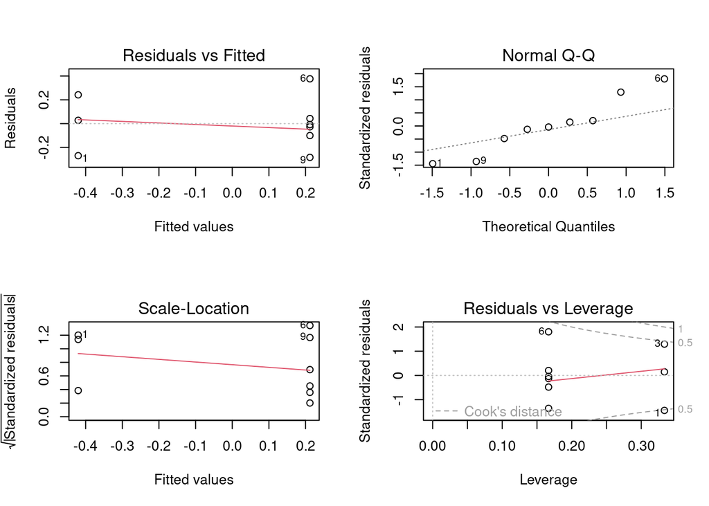

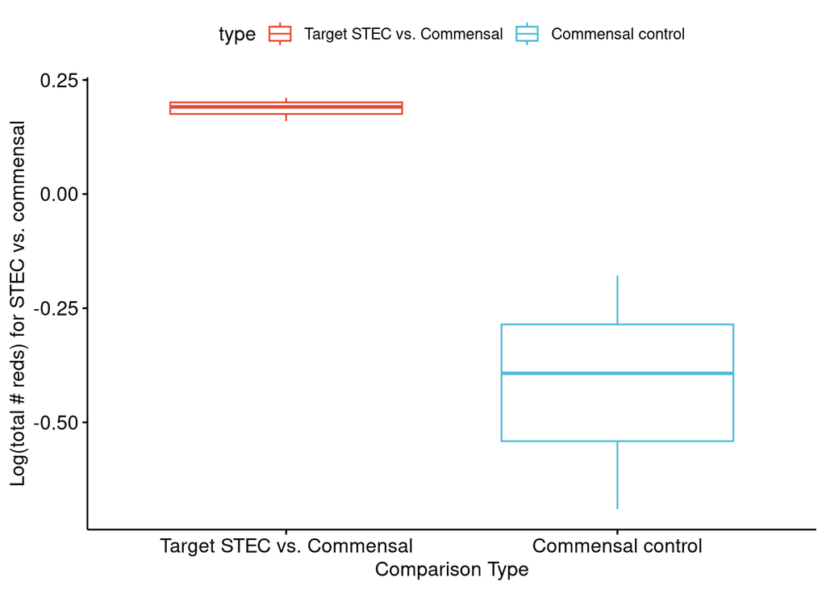